# Business Analytics Project

Tyler Young

11/12/2017

Background: A retail company changed it’s return policy by reducing the number of days customers had to make a return from 90 to 45 dayas, and would like to understand the effects on sales and returns. The transaction data is from an entire year. The policy change occured halfway through the year and only affected certain stores. The variable polchange is 0 for the first half of the year and 1 for the second half. The variable studygrp is 0 if the store did not change their return policy and 1 if the policy is changed. Therefore we look for significance in the interaction term between polchange and studygrp to determine if the new policy has an effect.

## read data

```r
storedata=read.csv("store attributes.csv")
transactiondata=read.csv("Transactions and customer attributes.txt",sep="\t")
```

## define needed variables

```r
transactiondata$polchange=ifelse(transactiondata$month_index<51,0,1) #policy change dummy variable. Before Oct. 1 = 0, after Oct. 1 = 1
transactiondata$studygrp=ifelse(transactiondata$store_number==10 | transactiondata$brand_number==8,0,1) #study group dummy variable. Sister brand = 0, all others = 1.
transactiondata$return_amount=transactiondata$return*transactiondata$net_purchase_amount
```

## set up data frames

```r
onlinedata=subset(transactiondata,brand_number==1)
physicaldata=subset(transactiondata,brand_number!=1)

physicalagg <- aggregate(physicaldata[c("net_purchase_amount","return_amount")], by=list(physicaldata$store_number, physicaldata$month_index,physicaldata$brand_number), sum) #aggregate physical store data by store number and month.  Also include brand number because some stores show up in the transaction data but not in the store data, and we will need brand number later.
colnames(physicalagg)[1] <- "store_number"
colnames(physicalagg)[2] <- "month_index"
colnames(physicalagg)[3] <- "brand_number"

onlineagg <- aggregate(onlinedata[c("net_purchase_amount","return_amount")], by=list(onlinedata$store_number, onlinedata$day,onlinedata$month_index), sum) #aggregate online storedata by store number and day. Also include month index to merge with store data later.
colnames(onlineagg)[1] <- "store_number"
colnames(onlineagg)[2] <- "day"
colnames(onlineagg)[3] <- "month_index"

onlined2=merge(onlineagg,storedata,by=c("store_number","month_index"),all.x=TRUE)
physicald2=merge(physicalagg,storedata,by=c("store_number","month_index"),all.x=TRUE)

onlined2$polchange=ifelse(onlined2$month_index<51,0,1)
onlined2$studygrp=ifelse(onlined2$store_number==10 | onlined2$Brand_number==8,0,1)
physicald2$polchange=ifelse(physicald2$month_index<51,0,1)
physicald2$studygrp=ifelse(physicald2$store_number==10 | physicald2$brand_number==8,0,1)


temp=aggregate(transactiondata[c("polchange","studygrp")],by=list(transactiondata$customer_id),mean) #take average of each customers policy change variable and study group variable.
colnames(temp)[1] <- "cust_id"
tempsub=subset(temp,polchange!=0 & polchange!=1) #take subset of customers that shopped before AND after the policy change.
x=subset(tempsub,studygrp==0 | studygrp==1) #Of the customers that shopped before and after the policy change, take the subset of customers that shopped exclusively at the sister brand or exclusively at non-sister brands
q5 = transactiondata[transactiondata$customer_id %in% x$cust_id,] #Now that we have identified the customers we want for question 5, we limit the transaction data to these customers.
custpurch = aggregate(q5[c("net_purchase_amount")], by=list(q5$customer_id, q5$polchange,q5$studygrp,q5$est_income_code,q5$gender,q5$age_band,q5$length_of_residence,q5$child),sum) #aggregate data by customer ID and policy change dummy variable. We include the other variables in case we need them for control variables in our model. We can do it this way because these extra variables only take one value for each customer, so they will not break up the data.
colnames(custpurch)[1] = "customer_id"
colnames(custpurch)[2] = "polchange"
colnames(custpurch)[3] = "studygrp"
colnames(custpurch)[4] = "est_income_code"
colnames(custpurch)[5] = "gender"
colnames(custpurch)[6] = "age_band"
colnames(custpurch)[7] = "length_of_residence"
colnames(custpurch)[8] = "child"


mergedata=merge(transactiondata,storedata,by=c("store_number","month"),all.x=TRUE)

#Use online2d for Q's 1&3, physical2d for Q's 2&4, custpurch for Q5, mergedata for Q6
```

## Question 1 - What is the impact of the change in the return policy on online sales

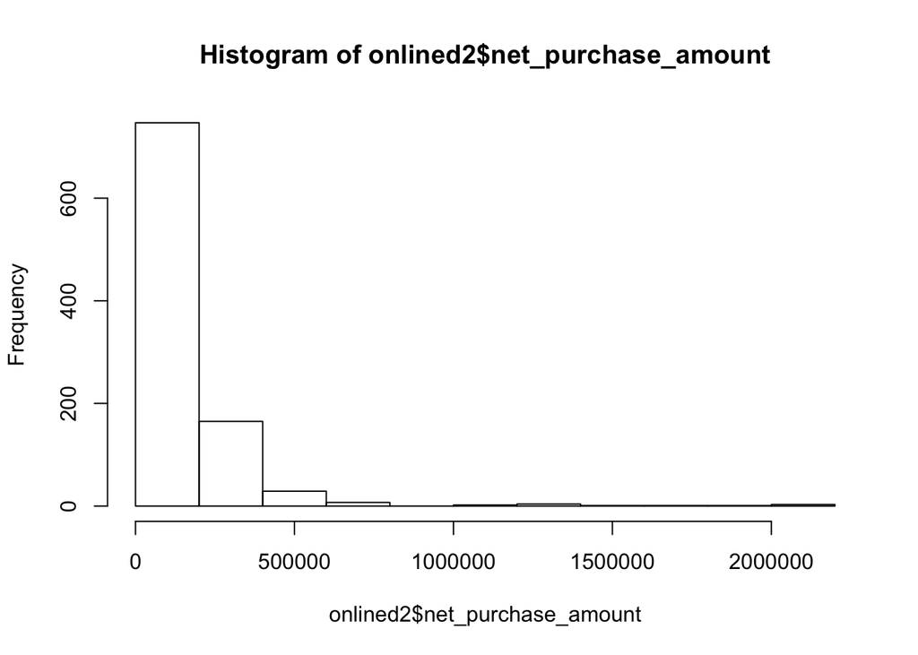

```r
hist(onlined2$net_purchase_amount)
```

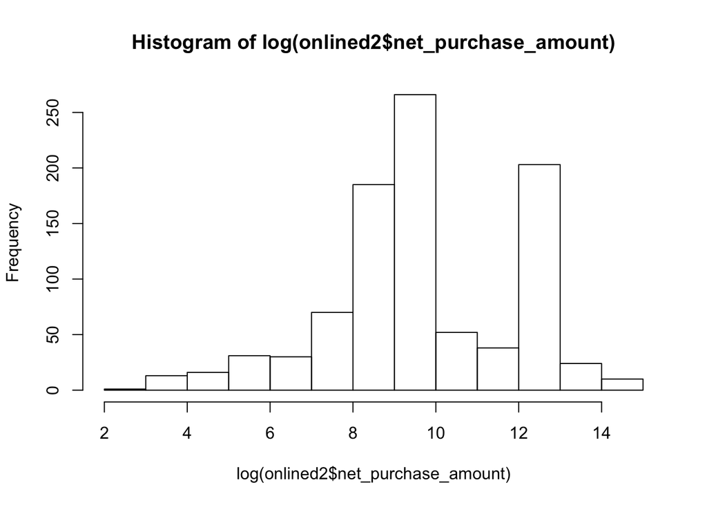

```r
hist(log(onlined2$net_purchase_amount)) #log transformation is more normally distributed, so we will use this as our dependent variable.

library(usdm)
```

```r
str(onlined2)
```

```
## 'data.frame':    960 obs. of  19 variables:
##  $ store_number        : int  10 10 10 10 10 10 10 10 10 10 ...
##  $ month_index         : int  45 45 45 45 45 45 45 45 45 45 ...
##  $ day                 : int  2 1 17 13 18 4 16 19 5 25 ...
##  $ net_purchase_amount : num  4517 10023 3922 0 2561 ...
##  $ return_amount       : num  204 796 172 0 0 ...
##  $ month               : Factor w/ 12 levels "APR","AUG","DEC",..: 1 1 1 1 1 1 1 1 1 1 ...
##  $ year                : int  2013 2013 2013 2013 2013 2013 2013 2013 2013 2013 ...
##  $ store_average_price : num  35.3 35.3 35.3 35.3 35.3 ...
##  $ store_number_of_skus: int  2543 2543 2543 2543 2543 2543 2543 2543 2543 2543 ...
##  $ sa_gender           : num  NA NA NA NA NA NA NA NA NA NA ...
##  $ sa_full_time        : num  NA NA NA NA NA NA NA NA NA NA ...
##  $ sa_avg_years_of_exp : num  NA NA NA NA NA NA NA NA NA NA ...
##  $ sa_married          : num  NA NA NA NA NA NA NA NA NA NA ...
##  $ sa_avg_rate_of_pay  : num  NA NA NA NA NA NA NA NA NA NA ...
##  $ sa_dependent        : num  0 0 0 0 0 0 0 0 0 0 ...
##  $ Brand_number        : int  1 1 1 1 1 1 1 1 1 1 ...
##  $ sales_volume_group  : int  4 4 4 4 4 4 4 4 4 4 ...
##  $ polchange           : num  0 0 0 0 0 0 0 0 0 0 ...
##  $ studygrp            : num  0 0 0 0 0 0 0 0 0 0 ...
```

```r
summary(onlined2)
```

```
##   store_number    month_index         day        net_purchase_amount
##  Min.   : 2.00   Min.   :45.00   Min.   :  1.0   Min.   :      0
##  1st Qu.: 2.00   1st Qu.:47.00   1st Qu.: 88.0   1st Qu.:   4138
##  Median : 6.00   Median :50.00   Median :178.0   Median :  12333
##  Mean   : 5.75   Mean   :50.35   Mean   :179.0   Mean   : 103682
##  3rd Qu.:10.00   3rd Qu.:53.00   3rd Qu.:265.2   3rd Qu.: 138976
##  Max.   :10.00   Max.   :56.00   Max.   :365.0   Max.   :2133233
##
##  return_amount          month          year      store_average_price
##  Min.   :     0.0   DEC    : 85   Min.   :2013   Min.   : 30.96
##  1st Qu.:   310.1   JUL    : 85   1st Qu.:2013   1st Qu.: 35.89
##  Median :  1549.6   APR    : 83   Median :2013   Median :194.45
##  Mean   : 14748.5   JAN    : 83   Mean   :2013   Mean   :172.53
##  3rd Qu.: 18883.4   MAY    : 83   3rd Qu.:2013   3rd Qu.:264.17
##  Max.   :254989.6   JUN    : 82   Max.   :2014   Max.   :286.87
##                     (Other):459
##  store_number_of_skus   sa_gender       sa_full_time
##  Min.   :  644        Min.   :0.7100   Min.   :0.6700
##  1st Qu.: 1492        1st Qu.:0.7800   1st Qu.:0.7200
##  Median : 2151        Median :0.8000   Median :0.7400
##  Mean   : 5365        Mean   :0.8018   Mean   :0.7781
##  3rd Qu.:10030        3rd Qu.:0.8100   3rd Qu.:0.7800
##  Max.   :20281        Max.   :1.0000   Max.   :1.0000
##                       NA's   :373      NA's   :373
##  sa_avg_years_of_exp   sa_married     sa_avg_rate_of_pay  sa_dependent
##  Min.   : 1.000      Min.   :0.0000   Min.   : 8.71      Min.   :0.0000
##  1st Qu.: 4.210      1st Qu.:0.3200   1st Qu.: 9.25      1st Qu.:0.0000
##  Median : 4.550      Median :0.3700   Median :10.22      Median :0.2700
##  Mean   : 5.047      Mean   :0.3296   Mean   :10.02      Mean   :0.1789
##  3rd Qu.: 5.220      3rd Qu.:0.3900   3rd Qu.:10.61      3rd Qu.:0.3025
##  Max.   :13.500      Max.   :0.6200   Max.   :11.05      Max.   :0.6000
##  NA's   :373         NA's   :373      NA's   :373
##   Brand_number sales_volume_group   polchange         studygrp
##  Min.   :1     Min.   :4.000      Min.   :0.0000   Min.   :0.000
##  1st Qu.:1     1st Qu.:4.000      1st Qu.:0.0000   1st Qu.:0.000
##  Median :1     Median :6.000      Median :0.0000   Median :1.000
##  Mean   :1     Mean   :5.398      Mean   :0.4844   Mean   :0.699
##  3rd Qu.:1     3rd Qu.:6.000      3rd Qu.:1.0000   3rd Qu.:1.000
##  Max.   :1     Max.   :6.000      Max.   :1.0000   Max.   :1.000
##
```

```r
df=data.frame(onlined2$store_number_of_skus,onlined2$studygrp,onlined2$polchange)
cor(df)
```

```
##                               onlined2.store_number_of_skus
## onlined2.store_number_of_skus                    1.00000000
## onlined2.studygrp                                0.41639704
## onlined2.polchange                               0.09986499
##                               onlined2.studygrp onlined2.polchange
## onlined2.store_number_of_skus      4.163970e-01       9.986499e-02
## onlined2.studygrp                  1.000000e+00      -7.099896e-05
## onlined2.polchange                -7.099896e-05       1.000000e+00
```

```r
vif(df) #VIF scores all < 3. We had to remove variables such as month_index and store_average_price because they generated VIF scores > 3.
```

```
##                       Variables      VIF
## 1 onlined2.store_number_of_skus 1.224538
## 2             onlined2.studygrp 1.212326
## 3            onlined2.polchange 1.012220
```

```r
model1=lm(log(net_purchase_amount+1)~studygrp*polchange+store_number_of_skus,data=onlined2)
summary(model1)
```

```
##
## Call:
## lm(formula = log(net_purchase_amount + 1) ~ studygrp * polchange +
##     store_number_of_skus, data = onlined2)
##
## Residuals:
##      Min       1Q   Median       3Q      Max
## -11.2495  -0.2045   0.7049   1.1557   3.3150
##
## Coefficients:
##                        Estimate Std. Error t value Pr(>|t|)
## (Intercept)           7.084e+00  1.709e-01  41.437  < 2e-16 ***
## studygrp              1.470e+00  2.098e-01   7.006 4.63e-12 ***
## polchange             1.359e-01  2.418e-01   0.562    0.574
## store_number_of_skus  2.683e-04  1.471e-05  18.232  < 2e-16 ***
## studygrp:polchange   -4.139e-01  2.895e-01  -1.430    0.153
## ---
## Signif. codes:  0 '***' 0.001 '**' 0.01 '*' 0.05 '.' 0.1 ' ' 1
##
## Residual standard error: 2.054 on 955 degrees of freedom
## Multiple R-squared:  0.3972, Adjusted R-squared:  0.3946
## F-statistic: 157.3 on 4 and 955 DF,  p-value: < 2.2e-16
```

```r
#results indicate that the interaction term is insignificant, implying that the policy change has no significant impact on online store sales

library(lmtest)
library(sandwich)
gqtest(model1)
```

```
##
##  Goldfeld-Quandt test
##
## data:  model1
## GQ = 0.89364, df1 = 475, df2 = 475, p-value = 0.8896
## alternative hypothesis: variance increases from segment 1 to 2
```

```r
bptest(model1) #no heteroscedasticity in either test
```

```
##
##  studentized Breusch-Pagan test
##
## data:  model1
## BP = 3.3471, df = 4, p-value = 0.5015
```

## Question 2 - What is the impact of the change in the return policy on physical sales

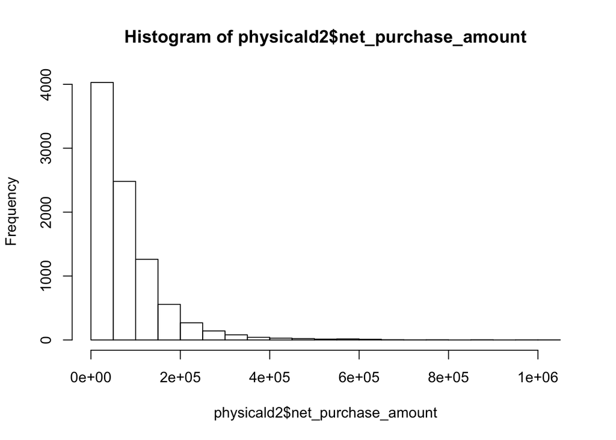

```r
hist(physicald2$net_purchase_amount)
```

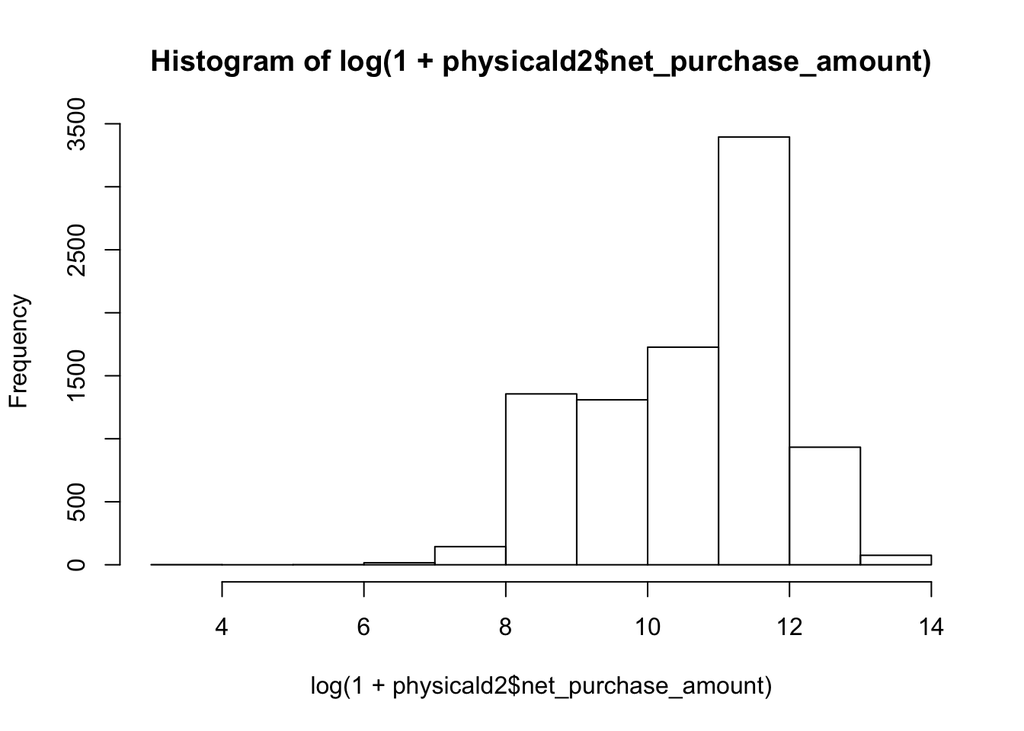

```r
hist(log(1 + physicald2$net_purchase_amount)) #again use log-transformed data
```

```r
#Checking Multi-collinearity
#Multi-collinearity for both df less than 3
library(usdm)
str(physicald2)
```

```
## 'data.frame':    8957 obs. of  19 variables:
##  $ store_number        : int  15 15 15 15 15 15 15 15 15 15 ...
##  $ month_index         : int  45 46 47 48 49 50 51 52 53 54 ...
##  $ brand_number        : int  8 8 8 8 8 8 8 8 8 8 ...
##  $ net_purchase_amount : num  7399 6232 6667 7479 11419 ...
##  $ return_amount       : num  1172 756 785 725 2339 ...
##  $ month               : Factor w/ 12 levels "APR","AUG","DEC",..: NA NA NA NA NA NA NA NA NA NA ...
##  $ year                : int  NA NA NA NA NA NA NA NA NA NA ...
##  $ store_average_price : num  NA NA NA NA NA NA NA NA NA NA ...
##  $ store_number_of_skus: int  NA NA NA NA NA NA NA NA NA NA ...
##  $ sa_gender           : num  NA NA NA NA NA NA NA NA NA NA ...
##  $ sa_full_time        : num  NA NA NA NA NA NA NA NA NA NA ...
##  $ sa_avg_years_of_exp : num  NA NA NA NA NA NA NA NA NA NA ...
##  $ sa_married          : num  NA NA NA NA NA NA NA NA NA NA ...
##  $ sa_avg_rate_of_pay  : num  NA NA NA NA NA NA NA NA NA NA ...
##  $ sa_dependent        : num  NA NA NA NA NA NA NA NA NA NA ...
##  $ Brand_number        : int  NA NA NA NA NA NA NA NA NA NA ...
##  $ sales_volume_group  : int  NA NA NA NA NA NA NA NA NA NA ...
##  $ polchange           : num  0 0 0 0 0 0 1 1 1 1 ...
##  $ studygrp            : num  0 0 0 0 0 0 0 0 0 0 ...
```

```r
summary(physicald2)
```

```
##   store_number   month_index     brand_number   net_purchase_amount
##  Min.   :  15   Min.   :45.00   Min.   :2.000   Min.   :     23
##  1st Qu.: 403   1st Qu.:47.00   1st Qu.:2.000   1st Qu.:  11435
##  Median :1469   Median :50.00   Median :3.000   Median :  58451
##  Mean   :1766   Mean   :50.45   Mean   :4.458   Mean   :  77197
##  3rd Qu.:2753   3rd Qu.:53.00   3rd Qu.:8.000   3rd Qu.: 105962
##  Max.   :4975   Max.   :56.00   Max.   :8.000   Max.   :1040980
##
##  return_amount        month           year      store_average_price
##  Min.   :     0   APR    : 562   Min.   :2013   Min.   :  18.86
##  1st Qu.:  1338   AUG    : 562   1st Qu.:2013   1st Qu.: 266.96
##  Median :  7011   DEC    : 562   Median :2013   Median : 392.73
##  Mean   : 11569   FEB    : 562   Mean   :2013   Mean   : 365.19
##  3rd Qu.: 16433   JAN    : 562   3rd Qu.:2013   3rd Qu.: 501.01
##  Max.   :142150   (Other):3934   Max.   :2014   Max.   :1280.65
##                   NA's   :2213   NA's   :2213   NA's   :2213
##  store_number_of_skus   sa_gender       sa_full_time
##  Min.   :  13.0       Min.   :0.0000   Min.   :0.0000
##  1st Qu.: 132.0       1st Qu.:0.7100   1st Qu.:0.5000
##  Median : 178.0       Median :0.8600   Median :0.6400
##  Mean   : 223.4       Mean   :0.8309   Mean   :0.6398
##  3rd Qu.: 245.0       3rd Qu.:1.0000   3rd Qu.:0.7500
##  Max.   :1775.0       Max.   :1.0000   Max.   :1.0000
##  NA's   :2213         NA's   :2215     NA's   :2215
##  sa_avg_years_of_exp   sa_married     sa_avg_rate_of_pay  sa_dependent
##  Min.   : 0.000      Min.   :0.0000   Min.   : 6.170     Min.   :0.000
##  1st Qu.: 2.000      1st Qu.:0.1700   1st Qu.: 8.860     1st Qu.:0.100
##  Median : 3.250      Median :0.3300   Median : 9.670     Median :0.200
##  Mean   : 3.846      Mean   :0.3303   Mean   : 9.835     Mean   :0.208
##  3rd Qu.: 5.220      3rd Qu.:0.5000   3rd Qu.:10.570     3rd Qu.:0.310
##  Max.   :17.330      Max.   :1.0000   Max.   :16.730     Max.   :0.830
##  NA's   :2215        NA's   :2215     NA's   :2215       NA's   :2213
##   Brand_number   sales_volume_group   polchange         studygrp
##  Min.   :2.000   Min.   :1.000      Min.   :0.0000   Min.   :0.0000
##  1st Qu.:2.000   1st Qu.:2.000      1st Qu.:0.0000   1st Qu.:0.0000
##  Median :3.000   Median :3.000      Median :0.0000   Median :1.0000
##  Mean   :3.818   Mean   :2.657      Mean   :0.4944   Mean   :0.6984
##  3rd Qu.:5.000   3rd Qu.:3.000      3rd Qu.:1.0000   3rd Qu.:1.0000
##  Max.   :8.000   Max.   :6.000      Max.   :1.0000   Max.   :1.0000
##  NA's   :2213    NA's   :2213
```